# Analyse exploratoire du jeu de données Heart Failure Prediction

Engel CALON, Bastien CUVILLIER, Camille MILON

### Heart Failure Prediction

##### Description

The “heart_failure_clinical_records.csv” dataset comprises clinical records of patients with heart failure, detailing various medical attributes that may contribute to heart failure incidents. This dataset is instrumental for researchers and healthcare professionals aiming to analyze factors leading to heart failure and mortality. The collected data spans individuals of varied ages, with measurements such as anaemia presence, creatinine phosphokinase levels, diabetes status, ejection fraction, high blood pressure, platelets count, serum creatinine, serum sodium levels, sex, smoking status, follow-up period (time), and the event of death.

##### Attribute Description

- age: Age of the patient (years)
- anaemia: Decrease of red blood cells or hemoglobin (0: No, 1: Yes)
- creatinine_phosphokinase: Level of the CPK enzyme in the blood (mcg/L)
- diabetes: If the patient has diabetes (0: No, 1: Yes)
- ejection_fraction: Percentage of blood leaving the heart at each contraction (%)
- high_blood_pressure: If the patient has hypertension (0: No, 1: Yes)
- platelets: Platelets in the blood (kiloplatelets/mL)
- serum_creatinine: Level of serum creatinine in the blood (mg/dL)
- serum_sodium: Level of serum sodium in the blood (mEq/L)
- sex: Biological sex of the patient (0: Female, 1: Male)
- smoking: If the patient smokes (0: No, 1: Yes)
- time: Follow-up period (days)
- DEATH_EVENT: If the patient deceased during the follow-up period (0: No, 1: Yes)

##### Use Case

This dataset can serve a vital role in machine learning projects and statistical analyses aiming to predict heart failure mortality and understand the impact of various predictors on heart failure outcomes. Researchers can use this data to develop predictive models, identify key risk factors, and propose targeted interventions for at-risk populations. Public health officials and policy makers can also leverage the insights gained to guide healthcare resource allocation and preventive strategies.

#### Chargement des données

```r
if(!require(here)) install.packages("here")
library(here)

# Chemin vers les données
data_path <- here("src", "data", "dataset_Heart_Failure_Prediction.txt")

# Lecture des données
clas_data <- read.table(
  data_path,
  header = FALSE,
  sep = ",",
  quote = "\"",
  stringsAsFactors = FALSE
)

# Aperçu
head(clas_data)
```

|  | V1 | V2 | V3 | V4 | V5 | V6 | V7 | V8 | V9 | V10 | V11 | V12 | V13 |
| --- | --- | --- | --- | --- | --- | --- | --- | --- | --- | --- | --- | --- | --- |
| 1 | 55 | 0 | 748 | 0 | 45 | 0 | 263358 | 1.3 | 137 | 1 | 1 | 88 | 0 |
| 2 | 65 | 0 | 56 | 0 | 25 | 0 | 305000 | 5.0 | 130 | 1 | 0 | 207 | 0 |
| 3 | 45 | 0 | 582 | 1 | 38 | 0 | 319000 | 0.9 | 140 | 0 | 0 | 244 | 0 |
| 4 | 60 | 1 | 754 | 1 | 40 | 1 | 328000 | 1.2 | 126 | 1 | 0 | 90 | 0 |
| 5 | 95 | 1 | 582 | 0 | 30 | 0 | 461000 | 2.0 | 132 | 1 | 0 | 50 | 1 |
| 6 | 70 | 0 | 232 | 1 | 30 | 0 | 302000 | 1.2 | 132 | 1 | 0 | 210 | 0 |

```r
# Renommer les colonnes
colnames(clas_data) <- c(
  "age",
  "anaemia",
  "creatinine_phosphokinase",
  "diabetes",
  "ejection_fraction",
  "high_blood_pressure",
  "platelets",
  "serum_creatinine",
  "serum_sodium",
  "sex",
  "smoking",
  "time",
  "DEATH_EVENT"
)

library(dplyr)
clas_data <- clas_data %>%
  mutate(
    age = as.integer(age),

    # variables logiques
    anaemia = as.logical(anaemia),
    diabetes = as.logical(diabetes),
    high_blood_pressure = as.logical(high_blood_pressure),
    sex = as.factor(sex),
    smoking = as.logical(smoking),

    # variable cible
    DEATH_EVENT = as.factor(DEATH_EVENT)
  )

head(clas_data)
```

|  | age | anaemia | creatinine_phosphokinase | diabetes | ejection_fraction | high_blood_pressure | platelets | serum_creatinine | serum_sodium | sex | smoking | time | DEATH_EVENT |
| --- | --- | --- | --- | --- | --- | --- | --- | --- | --- | --- | --- | --- | --- |
| 1 | 55 | FALSE | 748 | FALSE | 45 | FALSE | 263358 | 1.3 | 137 | 1 | TRUE | 88 | 0 |
| 2 | 65 | FALSE | 56 | FALSE | 25 | FALSE | 305000 | 5.0 | 130 | 1 | FALSE | 207 | 0 |
| 3 | 45 | FALSE | 582 | TRUE | 38 | FALSE | 319000 | 0.9 | 140 | 0 | FALSE | 244 | 0 |
| 4 | 60 | TRUE | 754 | TRUE | 40 | TRUE | 328000 | 1.2 | 126 | 1 | FALSE | 90 | 0 |
| 5 | 95 | TRUE | 582 | FALSE | 30 | FALSE | 461000 | 2.0 | 132 | 1 | FALSE | 50 | 1 |
| 6 | 70 | FALSE | 232 | TRUE | 30 | FALSE | 302000 | 1.2 | 132 | 1 | FALSE | 210 | 0 |

```r
cat("Dimensions du dataset :", dim(clas_data), "\n\n")
```

```
Dimensions du dataset : 5000 13
```

```r
cat("Structure du dataset :\n")
```

```
Structure du dataset :
```

```r
str(clas_data)
```

```
'data.frame':   5000 obs. of  13 variables:
 $ age                     : int  55 65 45 60 95 70 63 70 50 53 ...
 $ anaemia                 : logi  FALSE FALSE FALSE TRUE TRUE FALSE ...
 $ creatinine_phosphokinase: num  748 56 582 754 582 232 122 171 482 446 ...
 $ diabetes                : logi  FALSE FALSE TRUE TRUE FALSE TRUE ...
 $ ejection_fraction       : num  45 25 38 40 30 30 60 50 30 45 ...
 $ high_blood_pressure     : logi  FALSE FALSE FALSE TRUE FALSE FALSE ...
 $ platelets               : num  263358 305000 319000 328000 461000 ...
 $ serum_creatinine        : num  1.3 5 0.9 1.2 2 1.2 1.2 0.9 0.9 1 ...
 $ serum_sodium            : num  137 130 140 126 132 132 145 141 132 133 ...
 $ sex                     : Factor w/ 2 levels "0","1": 2 2 1 2 2 2 1 1 2 2 ...
 $ smoking                 : logi  TRUE FALSE FALSE FALSE FALSE FALSE ...
 $ time                    : num  88 207 244 90 50 210 147 196 109 215 ...
 $ DEATH_EVENT             : Factor w/ 2 levels "0","1": 1 1 1 1 2 1 1 1 1 1 ...
```

#### Résumé statistique

```r
summary(clas_data)
```

```
      age         anaemia        creatinine_phosphokinase  diabetes       ejection_fraction high_blood_pressure
 Min.   :40.00   Mode :logical   Min.   :  23.0           Mode :logical   Min.   :14.00     Mode :logical
 1st Qu.:50.00   FALSE:2628      1st Qu.: 121.0           FALSE:2803      1st Qu.:30.00     FALSE:3176
 Median :60.00   TRUE :2372      Median : 248.0           TRUE :2197      Median :38.00     TRUE :1824
 Mean   :60.28                   Mean   : 586.8                           Mean   :37.73
 3rd Qu.:68.00                   3rd Qu.: 582.0                           3rd Qu.:45.00
 Max.   :95.00                   Max.   :7861.0                           Max.   :80.00
   platelets      serum_creatinine  serum_sodium   sex       smoking             time       DEATH_EVENT
 Min.   : 25100   Min.   :0.500    Min.   :113.0   0:1772   Mode :logical   Min.   :  4.0   0:3432
 1st Qu.:215000   1st Qu.:0.900    1st Qu.:134.0   1:3228   FALSE:3441      1st Qu.: 74.0   1:1568
 Median :263358   Median :1.100    Median :137.0            TRUE :1559      Median :113.0
 Mean   :265075   Mean   :1.369    Mean   :136.8                            Mean   :130.7
 3rd Qu.:310000   3rd Qu.:1.400    3rd Qu.:140.0                            3rd Qu.:201.0
 Max.   :850000   Max.   :9.400    Max.   :148.0                            Max.   :285.0
```

##### Variables numériques

**age**

- Min = 40
- Médiane = 60
- Moyenne = 60.3

Population plutôt âgée, cohérente avec l’insuffisance cardiaque.

**creatinine_phosphokinase (CPK)**

- Min = 23
- Max = 7861 !!!
- Médiane = 248
- Moyenne = 586

Très forte asymétrie positive  
Présence d’extrêmes massifs  
Médiane << moyenne => valeurs extraordinaires

*Normalisation nécessaire* (surtout pour les modèles linéaires) et potentiellement *transformation log*

**ejection_fraction**

- Min : 14
- Max : 80
- Médiane : 38
- Moyenne : 37.7

*Variable particulièrement intéressante* dans le cadre de la prédiction => Ejection fraction < 40 = cœur faible  
On observe peu de valeurs très élevées (≥ 70) et on s’attend à avoir un pic entre 30 et 40.

**platelets (plaquettes)**

Valeurs très élevées et amplitude énorme

Probable forte asymétrie (à vérifier avec l’étude de la distribution)

Transformation log à envisager

**serum_creatinine**

- Min : 0.5
- Max : 9.4
- Médiane : 1.1
- Moyenne : 1.37

Distribution fortement asymétrique avec quelques patients en insuffisance rénale sévère (créatinine > 4). Cette variable est un fort prédicteur du décès selon les études cliniques.

**serum_sodium**

- Min : 113
- Max : 148
- Médiane : 137

Variable étroite, distribution probablement quasi normale (à vérifier)  
Les faibles valeurs (< 132) sont cliniquement significatives (hyponatrémie => risque accru de décès).

**time (follow-up days)**

- Min : 4
- Max : 285
- Médiane : 113
- Moyenne : 130

Distribution asymétrique positive  
Variable importante mais post-mortem (ne doit généralement pas être utilisée en prédiction prospective) => à supprimer

##### Variables catégorielles

**anemia**  
Représentation équilibrée

**diabetes**  
Équilibrée

**high_blood_pressure**  
36% oui => déséquilibré

**sex**  
65% hommes => déséquilibré

**smoking**  
31% oui => déséquilibré

**DEATH_EVENT**  
31% décès Déséquilibre de la variable cible à prendre en compte pour la classification !!

```r
# Nombre de valeurs manquantes
colSums(is.na(clas_data))
```

```
                     age                  anaemia creatinine_phosphokinase                 diabetes
                       0                        0                        0                        0
       ejection_fraction      high_blood_pressure                platelets         serum_creatinine
                       0                        0                        0                        0
            serum_sodium                      sex                  smoking                     time
                       0                        0                        0                        0
             DEATH_EVENT
                       0
```

Aucune valeur manquante n’a été détectée.

#### Distributions

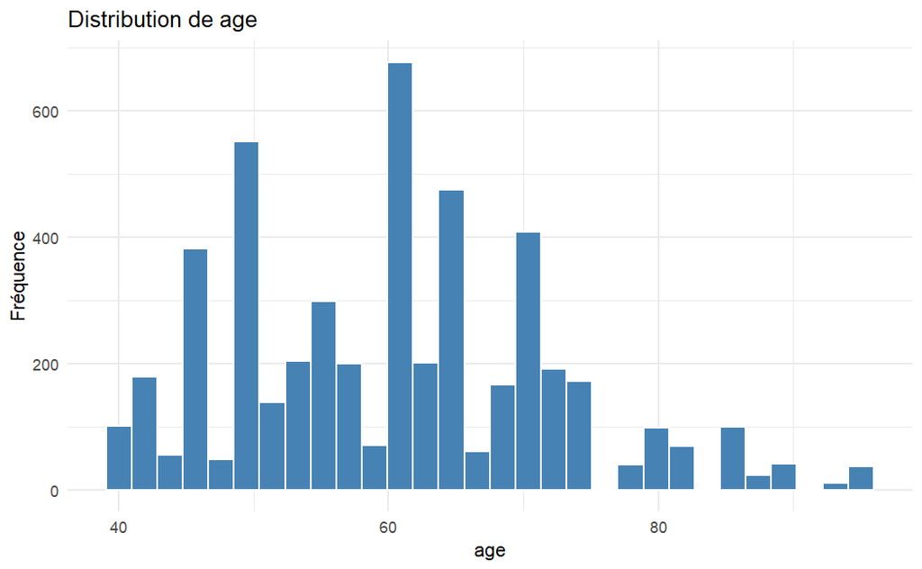

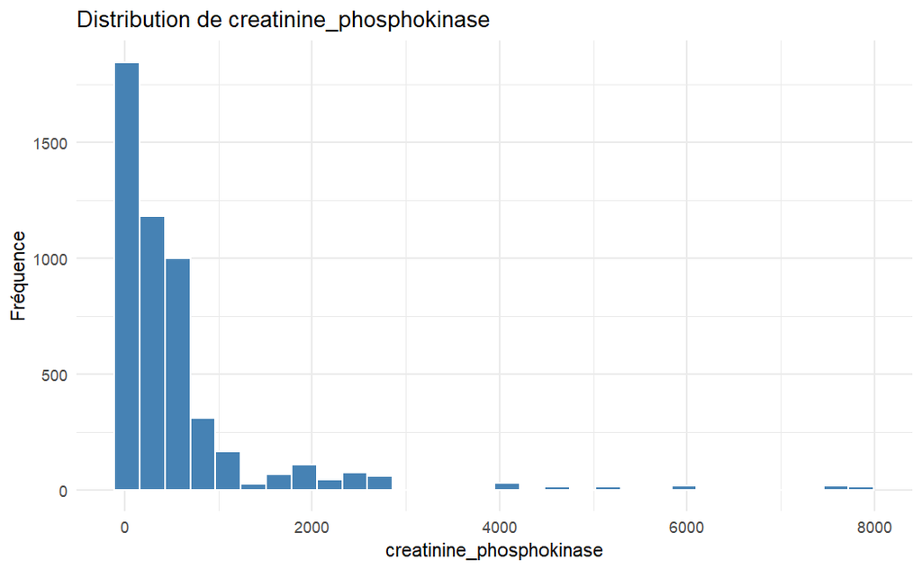

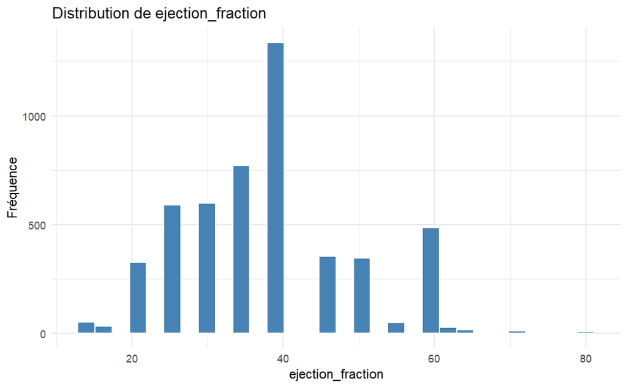

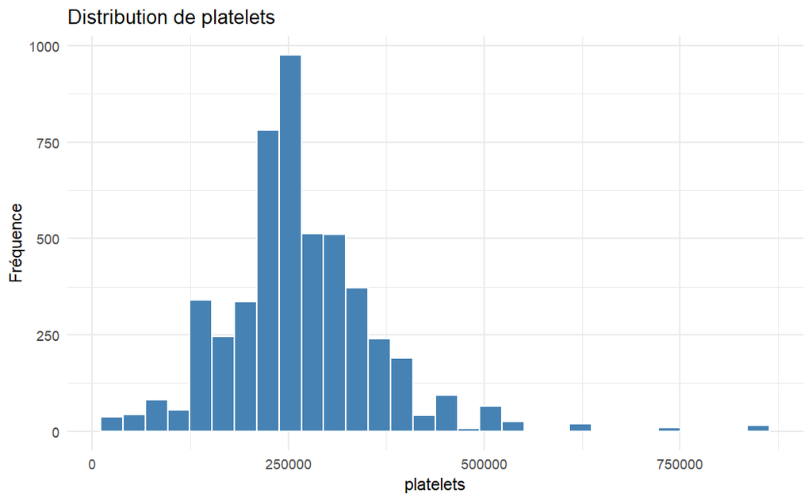

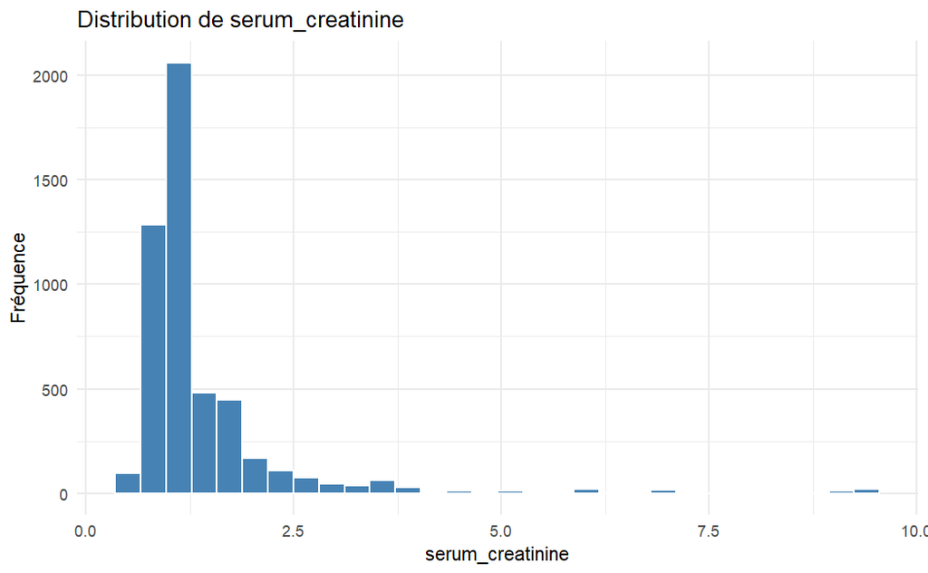

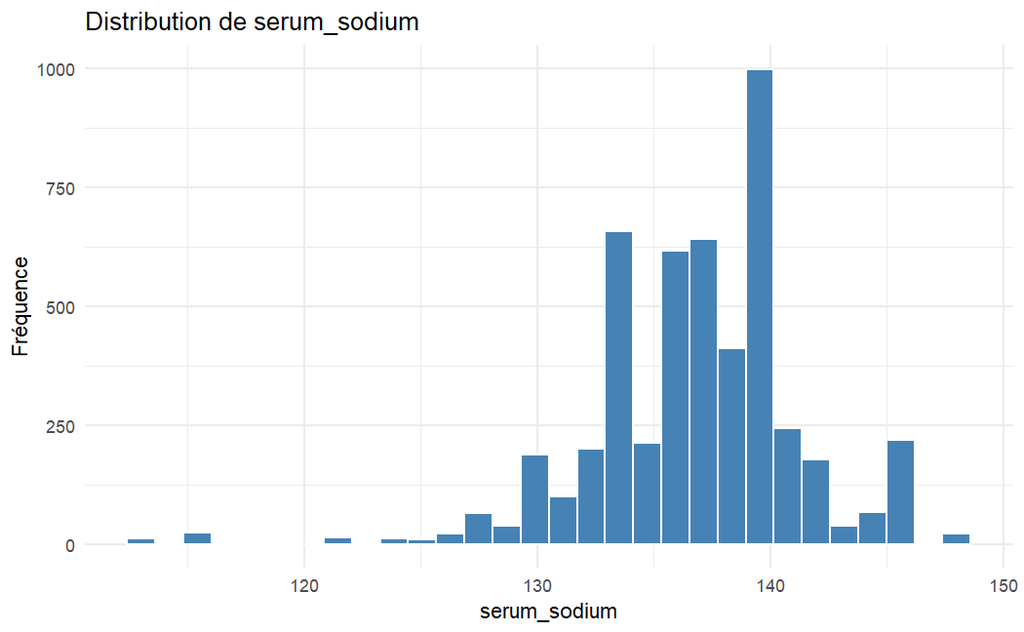

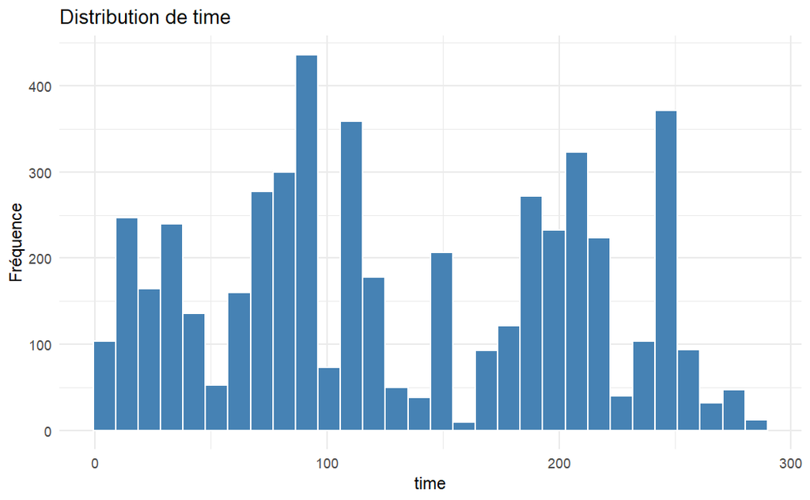

```r
library(tidyverse)
# Histogrammes
num_vars <- names(clas_data)[sapply(clas_data, is.numeric)]

for (var in num_vars) {
  print(
    ggplot(clas_data, aes_string(x = var)) +
      geom_histogram(bins = 30, fill = "steelblue", color = "white") +
      labs(title = paste("Distribution de", var), x = var, y = "Fréquence") +
      theme_minimal()
  )
}
```

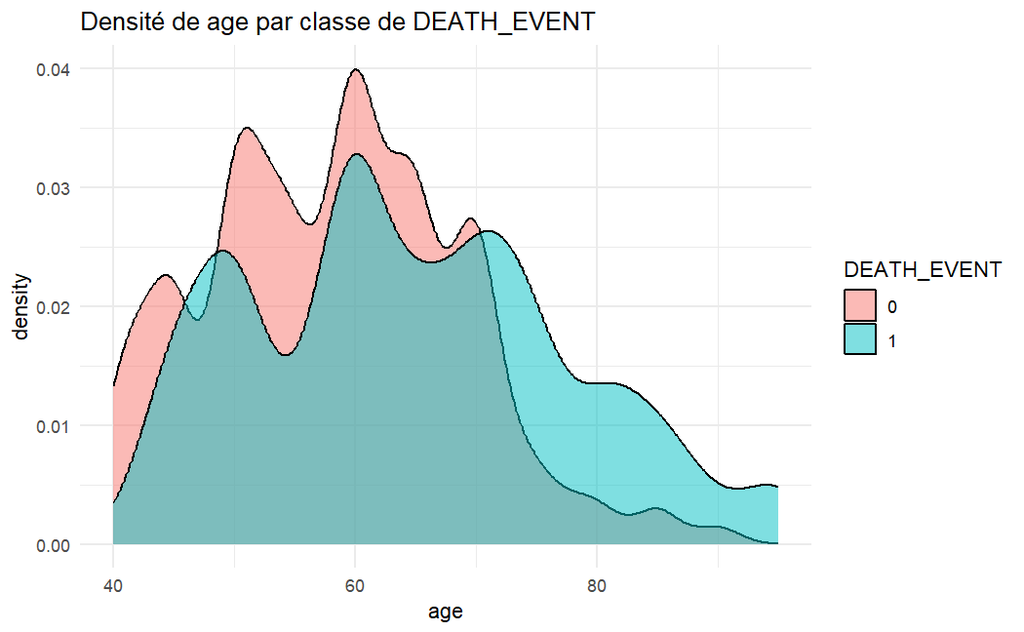

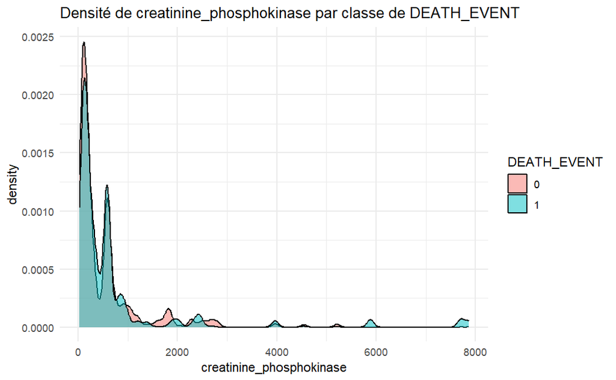

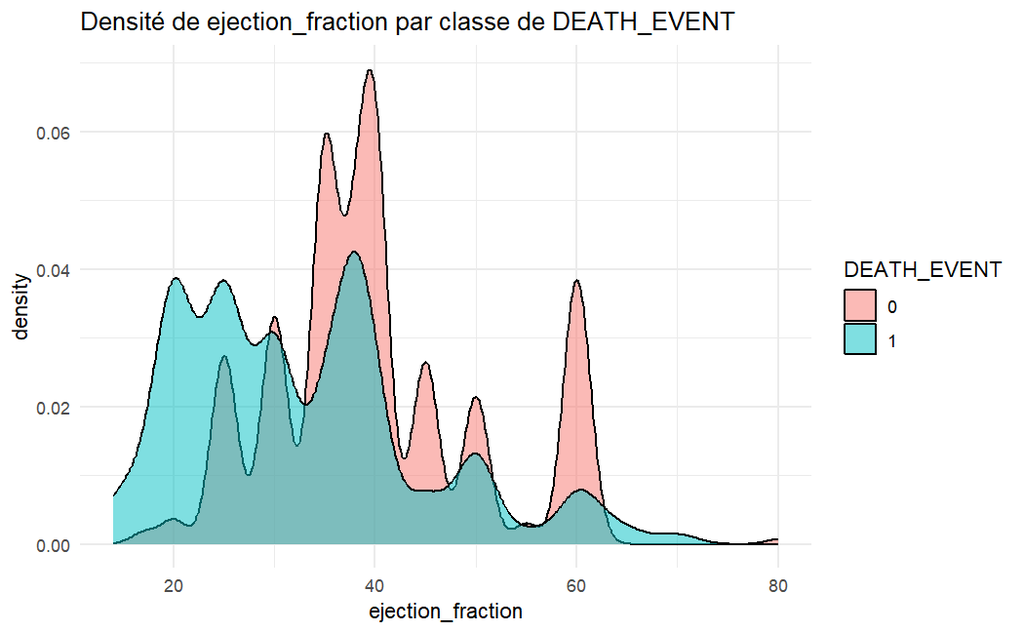

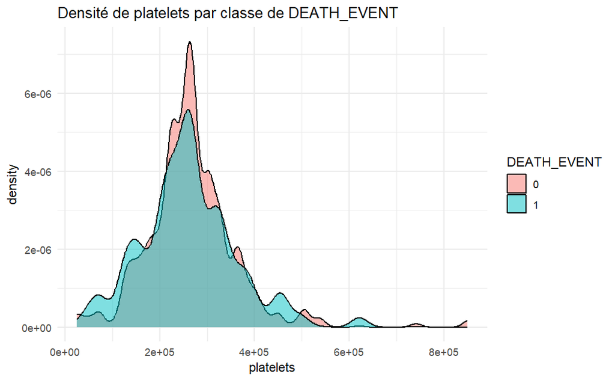

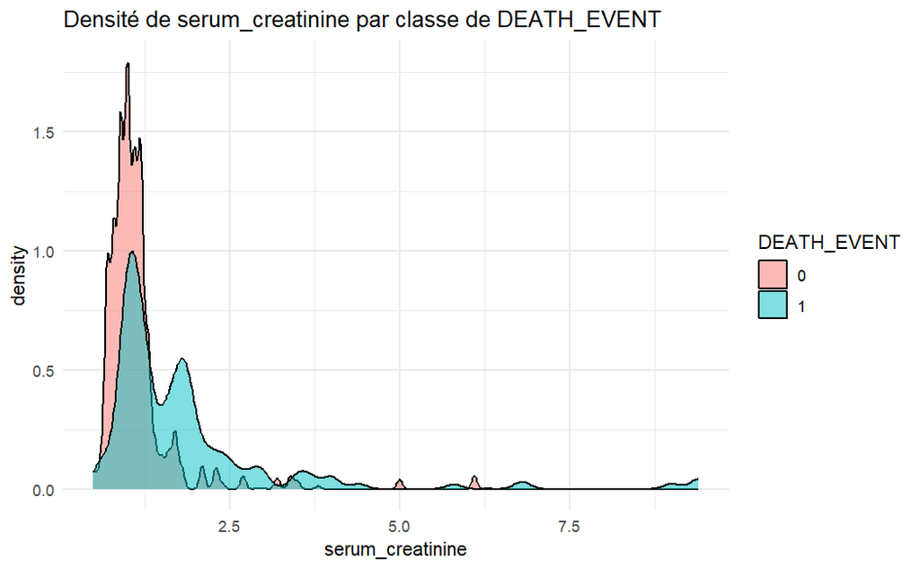

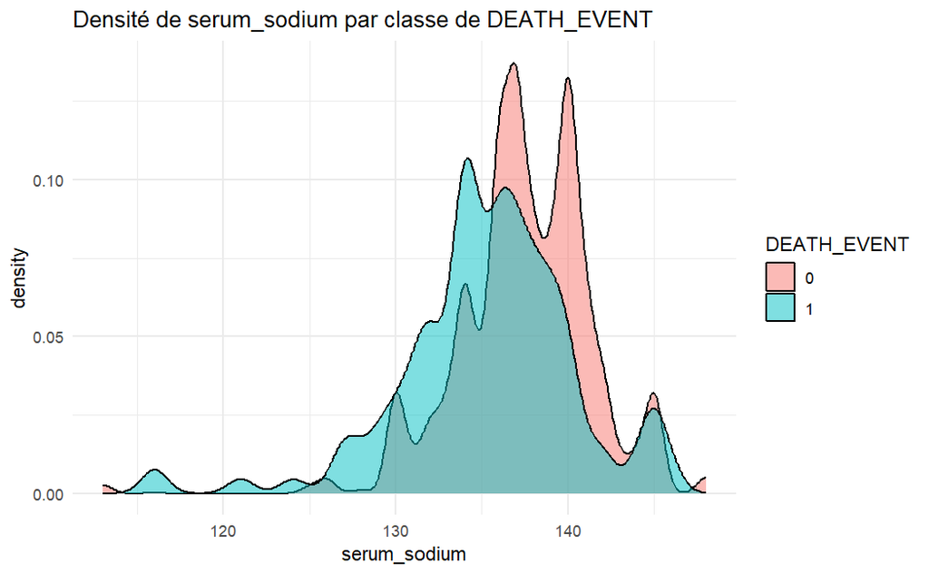

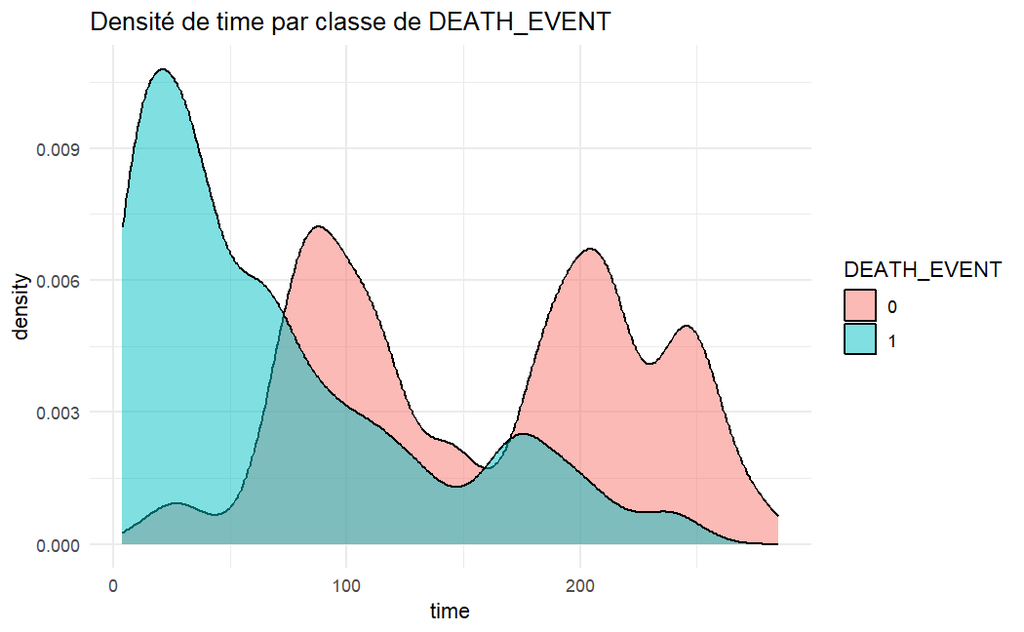

```r
# Densités par classe
for (var in num_vars) {
  print(
    ggplot(clas_data, aes_string(x = var, fill = "DEATH_EVENT")) +
      geom_density(alpha = 0.5) +
      labs(title = paste("Densité de", var, "par classe de DEATH_EVENT")) +
      theme_minimal()
  )
}
```

##### Distributions

- **age** s’apparente à une gaussienne mais n’est pas gaussienne
- **creatinine_phosphokinase** => exponentielle décroissante, présence des valeurs extraordinaires
- **ejection_fraction** s’apparente à une gaussienne mais n’est pas gaussienne, asymétrie (plus de valeurs inférieures ou égales à 40 que supérieures)
- **platelets** ressemble à une gaussienne avec des valeurs aberrantes à droite => les valeurs extrêmes doivent être examinées mais semblent plausibles biologiquement
- **serum_creatinine** semble suivre une loi de Fisher
- **serum_sodium** n’est pas une loi de Fisher mais s’apparente à une loi de Fisher inversée
- **time** suit une distribution aléatoire

##### Densités par classe

- **age** : Le diagramme de densité nous permet d’observer une légère discrimination: les personnes atteintes de problèmes cardiaques âgées de 70 ans ou plus ont tendance à mourir
- **ejection_fraction** : Légère discrimination possible : ejection_fraction élevée => survie; ejection_fraction faible => mort
- **time** : Variable discriminante mais seulement utilisable post-mortem donc pas grand intérêt => comme expliqué précédemment, cette variable est à supprimer du jeu de données

#### Analyse bivariée

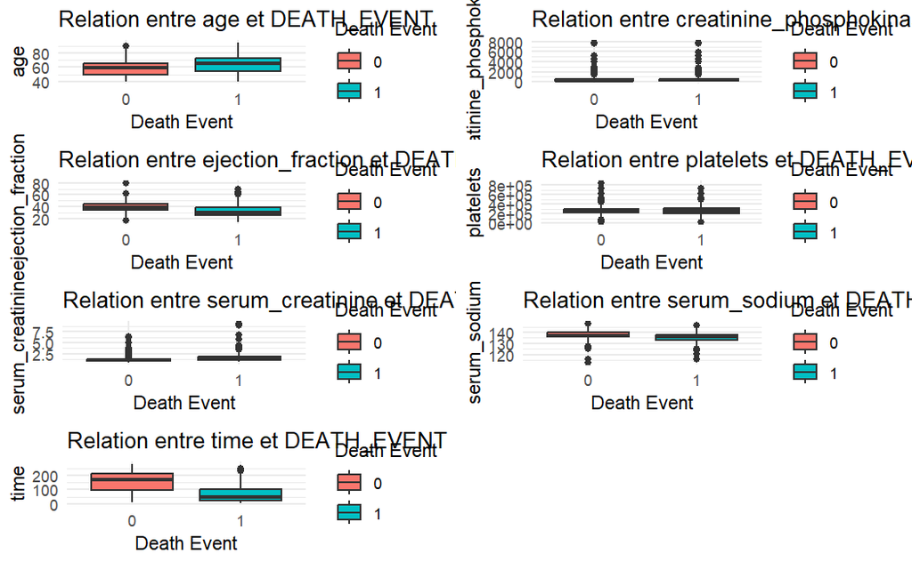

```r
library(ggplot2)
library(gridExtra)
num_vars <- clas_data %>% select(age, creatinine_phosphokinase, ejection_fraction,
                          platelets, serum_creatinine, serum_sodium, time)

plots_num_target <- lapply(names(num_vars), function(v) {
  ggplot(clas_data, aes_string(x = "as.factor(DEATH_EVENT)", y = v, fill = "as.factor(DEATH_EVENT)")) +
    geom_boxplot() +
    theme_minimal() +
    labs(title = paste("Relation entre", v, "et DEATH_EVENT"),
         x = "Death Event", fill = "Death Event")
})
grid.arrange(grobs = plots_num_target, ncol = 2)
```

Les boxplots confirment les observations des graphiques de densité par classe.

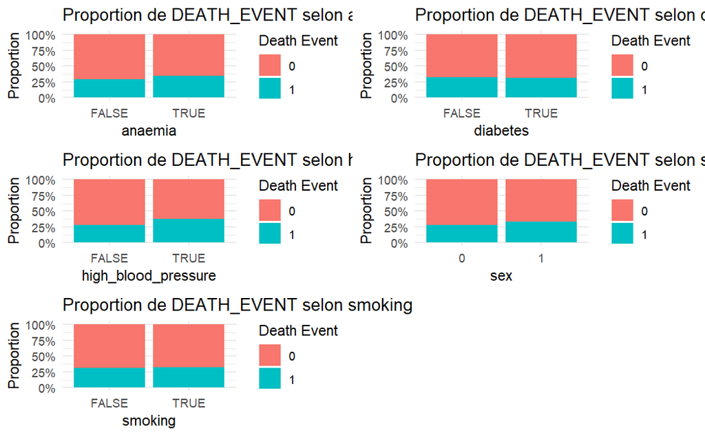

```r
cat_vars <- clas_data %>% select(anaemia, diabetes, high_blood_pressure, sex,
                          smoking, DEATH_EVENT)

plots_cat_target <- lapply(names(cat_vars)[-length(names(cat_vars))], function(v) {
  ggplot(clas_data, aes_string(x = v, fill = "as.factor(DEATH_EVENT)")) +
    geom_bar(position = "fill") +
    scale_y_continuous(labels = scales::percent) +
    theme_minimal() +
    labs(title = paste("Proportion de DEATH_EVENT selon", v),
         y = "Proportion", fill = "Death Event")
})
grid.arrange(grobs = plots_cat_target, ncol = 2)
```

Aucune variable catégorielle ne semble déterminante à elle seule pour la prédiction de DEATH_EVENT.

Conclusion => les variables les plus discriminantes semblent être :  
- ejection_fraction  
- serum_creatinine  
- age  
- serum_sodium (modérément)

#### Corrélation

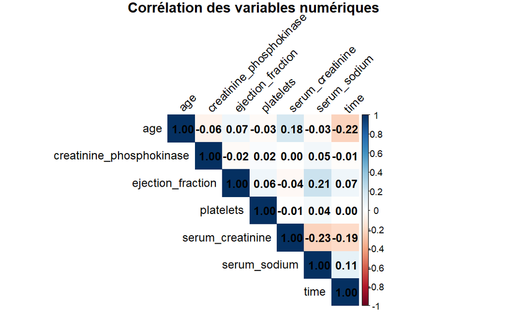

```r
library(corrplot)
cor_mat <- cor(num_vars)
corrplot(cor_mat, method = "color",
         type = "upper", addCoef.col = "black",
         tl.col = "black", tl.srt = 45,
         title = "Corrélation des variables numériques",
         mar = c(0, 0, 1, 0))
```

On observe aucune forte corrélation entre les différentes variables numériques => Pas besoin de sélection de variables basée sur colinéarité

#### Répartition des classes

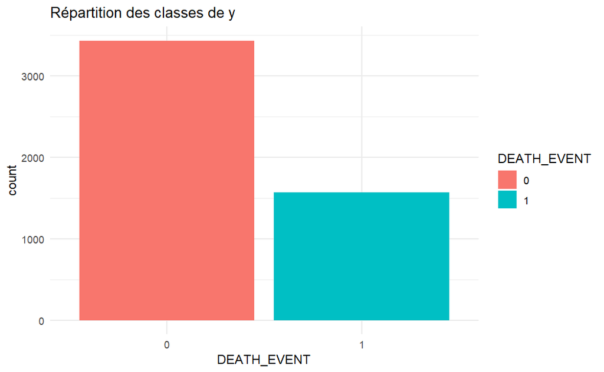

```r
ggplot(clas_data, aes(x = DEATH_EVENT, fill = DEATH_EVENT)) +
  geom_bar() +
  labs(title = "Répartition des classes de y") +
  theme_minimal()
```

Cela confirme l’hypothèse selon laquelle la **classe 1 (mort) est sous-représentée** => A gérer pour l’apprentissage

#### Test de plusieurs classifieurs

```r
library(dplyr)
library(ggplot2)
library(randomForest)
library(xgboost)
library(pROC)
set.seed(123)


##### Préparation des données #####

data <- clas_data %>%
  select(-time) %>%            # Supprimer variable post-mortem !
  mutate(
    DEATH_EVENT = factor(DEATH_EVENT, levels = c(0,1)),
    anaemia = factor(anaemia),
    diabetes = factor(diabetes),
    high_blood_pressure = factor(high_blood_pressure),
    sex = factor(sex),
    smoking = factor(smoking)
  )

data_xgb <- clas_data %>%
  select(-time) %>%
  mutate(
    age = as.integer(age),

    # variables logiques  => à vérifier selon les modèles s'il est plus intéressant de les avoir as logical ou as factor
    anaemia = as.logical(anaemia),
    diabetes = as.logical(diabetes),
    high_blood_pressure = as.logical(high_blood_pressure),
    sex = as.logical(sex),
    smoking = as.logical(smoking),

    # variable cible
    DEATH_EVENT = factor(DEATH_EVENT, levels = c(0,1))
  )

# Transformation log des variables très asymétriques
data <- data %>%
  mutate(
    creatinine_phosphokinase_log = log1p(creatinine_phosphokinase),
    platelets_log = log1p(platelets),
    serum_creatinine_log = log1p(serum_creatinine)
  ) %>%
  select(-creatinine_phosphokinase, -platelets, -serum_creatinine)

data_xgb <- data_xgb %>%
  mutate(
    creatinine_phosphokinase_log = log1p(creatinine_phosphokinase),
    platelets_log = log1p(platelets),
    serum_creatinine_log = log1p(serum_creatinine)
  ) %>%
  select(-creatinine_phosphokinase, -platelets, -serum_creatinine)

# Séparer X et y
X <- data %>% select(-DEATH_EVENT)
y <- data$DEATH_EVENT
X_xgb <- data_xgb %>% select(-DEATH_EVENT)
y_xgb <- data$DEATH_EVENT


##### Validation croisée 5-fold #####

k <- 5
n <- nrow(data)
folds <- split(sample(1:n), rep(1:k, length.out = n))

# Fonction pour calculer Accuracy et AUC
eval_metrics <- function(y_true, y_pred_prob, threshold = 0.5) {
  y_pred <- factor(ifelse(y_pred_prob >= threshold, 1, 0), levels = c(0,1))
  acc <- mean(y_true == y_pred)
  auc <- pROC::roc(as.numeric(as.character(y_true)), y_pred_prob)$auc
  return(list(Accuracy = acc, AUC = auc))
}

results <- list(Logistic = list(), RF = list(), XGB = list())

for (i in 1:k) {
  test_idx <- folds[[i]]
  train_idx <- setdiff(1:n, test_idx)

  X_train <- X[train_idx, ]
  y_train <- y[train_idx]
  X_test <- X[test_idx, ]
  y_test <- y[test_idx]
  X_train_xgb <- X_xgb[train_idx, ]
  y_train_xgb <- y_xgb[train_idx]
  X_test_xgb <- X_xgb[test_idx, ]
  y_test_xgb <- y_xgb[test_idx]


  # Régression logistique
  df_train <- data.frame(y = y_train, X_train)
  log_mod <- glm(y ~ ., data = df_train, family = binomial)
  pred_log <- predict(log_mod, newdata = X_test, type = "response")
  results$Logistic[[i]] <- eval_metrics(y_test, pred_log)


  # Random Forest
  rf_mod <- randomForest(x = X_train, y = y_train, ntree = 2) # Tester le nb d'arbres optimal !! => Vérifier le TD
  pred_rf <- predict(rf_mod, newdata = X_test, type = "prob")[,2]
  results$RF[[i]] <- eval_metrics(y_test, pred_rf)


  # XGBoost
  #Fonction pour transformer facteurs ou logical en numériques 0 et 1
  encode_numeric <- function(df) {
    df[] <- lapply(df, function(col) {
      if (is.logical(col)) {
        as.numeric(col)
      } else if (is.factor(col)) {
        as.numeric(as.character(col))
      } else {
        as.numeric(col)
      }
    })
    return(as.matrix(df))
  }

  X_train_xgb <- encode_numeric(X_train_xgb)
  X_test_xgb <- encode_numeric(X_test_xgb)

  dtrain <- xgb.DMatrix(data = X_train_xgb, label = as.numeric(as.character(y_train)))
  dtest  <- xgb.DMatrix(data = X_test_xgb, label = as.numeric(as.character(y_test)))

  xgb_mod <- xgboost(
    data = dtrain,
    objective = "binary:logistic",
    nrounds = 100,
    max_depth = 3,
    eta = 0.1,
    verbose = 0
  )
  pred_xgb <- predict(xgb_mod, dtest)
  results$XGB[[i]] <- eval_metrics(y_test, pred_xgb)
}


##### Résultats #####

summarize_results <- function(res_list) {
  acc <- sapply(res_list, function(x) x$Accuracy)
  auc <- sapply(res_list, function(x) x$AUC)
  data.frame(
    Accuracy_Mean = mean(acc),
    Accuracy_SD = sd(acc),
    AUC_Mean = mean(auc),
    AUC_SD = sd(auc)
  )
}

res_df <- rbind(
  Logistic = summarize_results(results$Logistic),
  RF = summarize_results(results$RF),
  XGB = summarize_results(results$XGB)
)

print(res_df)
```

|  | Accuracy_Mean | Accuracy_SD | AUC_Mean | AUC_SD |
| --- | --- | --- | --- | --- |
| Logistic | 0.7798 | 0.018965759 | 0.8191267 | 0.014556954 |
| RF | 0.9686 | 0.005029911 | 0.9824588 | 0.005441288 |
| XGB | 0.9276 | 0.008234076 | 0.9711592 | 0.002992234 |

```r
NA
```